# Ensemble Classifiers

Ivet A., Laura A., Arnau G.

# Introduction

The goal of this task is to test our knowledge on building predictive models using ensemble based tree models, as well as to help us consolidate the whole process of building a predictive pipeline.

We will work with a real cancer dataset where researchers aimed to predict recurrence (re-appearance of disease some time after treatment) using the concentrations of 101 distinct peptides that had been related with this process (so they were putative recurrence biomarkers). Data are available from the `cancerDat.csv`. On the other hand, `cancerInfo.csv` contains information on the groups defined by the recurrence and the site the samples came from.

The researchers had previously attempted to use some statistical models that did not perform very well, so we are asked to try using an ensemble biomarker, the best of a random forest or a boosted classifier.

Let’s load the data:

```r
cancerData <- read.csv("cancerDat.csv", sep = ";")
cancerInfo <- read.csv("cancerInfo.csv", sep = ";")
```

# Exploratory data analysis

A first step is to have a look at the data, so we display the first rows of `cancerData`:

```r
head(cancerData)
```

|  | X | NO.REC_1 | NO.REC_2 | NO.REC_3 | NO.REC_4 | NO.REC_5 | NO.REC_6 | NO.REC_7 | NO.REC_8 | NO.REC_9 | NO.REC_10 | NO.REC_11 | NO.REC_12 | NO.REC_13 | NO.REC_14 | NO.REC_15 | NO.REC_16 | NO.REC_17 | NO.REC_18 | NO.REC_19 | NO.REC_20 | NO.REC_21 | NO.REC_22 | NO.REC_23 | NO.REC_24 | NO.REC_25 | NO.REC_26 | NO.REC_27 | NO.REC_28 | … |
| --- | --- | --- | --- | --- | --- | --- | --- | --- | --- | --- | --- | --- | --- | --- | --- | --- | --- | --- | --- | --- | --- | --- | --- | --- | --- | --- | --- | --- | --- | --- |
| 1 | RPAB3_ADQFEYVMYGK | 21,92347241 | 21,02016455 | 19,58578813 | 19,06176708 | 18,54702924 | 20,97764063 | 21,40669464 | 21,12959375 | 19,75994453 | 21,35210003 | 21,72353893 | 21,11175684 | 21,57135158 | 17,60909472 | 22,31594575 | 20,63085792 | 20,72571736 | 18,75944519 | 21,67397309 | 20,70671626 | 21,3976224 | 21,31782978 | 18,34743563 | 21,86630371 | 18,21311792 | 18,0152433 | 20,91644224 | 21,77164607 | … |
| 2 | LSM8_AEPLNSVAH | 24,44261712 | 23,64984078 | 23,7361284 | 23,37486512 | 23,03958824 | 23,34131462 | 22,99352114 | 23,21786969 | 22,89169167 | 23,83164594 | 23,76480484 | 23,50778738 | 24,08937076 | 22,06022774 | 23,58931505 | 24,23687693 | 23,10536926 | 22,78158681 | 24,23073143 | 23,57516615 | 23,49459511 | 23,86105025 | 22,62681621 | 24,32094837 | 22,37543501 | 22,44567992 | 22,57322358 | 24,22938692 | … |
| 3 | BUD23_AGFSGGMVVDYPNSAK | 19,05056228 | 18,40241268 | 18,19152746 | 17,69277508 | 19,06697285 | 18,80590029 | 18,94474859 | 18,32459978 | 18,40622942 | 18,74473061 | 19,95324634 | 16,46795404 | 18,12460093 | 17,55037151 | 19,28156447 | 18,83630274 | 18,41375246 | 18,26356965 | 20,10719289 | 17,71436828 | 19,08429019 | 18,99702486 | 18,22676215 | 19,73595966 | 17,60069639 | 16,98690119 | 18,54253344 | 19,68914912 | … |
| 4 | TLN1_ALEATTEHIR | 18,48266729 | 19,0889964 | 16,33124044 | 15,36272046 | 15,83572129 | 19,56179352 | 19,40112904 | 17,48425834 | 17,23278084 | 18,12664884 | 19,44126356 | 18,50108077 | 18,9180834 | 15,33975132 | 18,5865517 | 17,37364707 | 19,34568195 | 15,11996564 | 16,54662516 | 18,79615681 | 19,27050246 | 18,34150977 | 16,41396378 | 19,14302256 | 17,02294369 | 18,4595114 | 19,1305423 | 18,4130529 | … |
| 5 | MOES_ALTSELANAR | 24,08679289 | 24,7103227 | 21,91732551 | 21,48492428 | 21,33958748 | 24,30460173 | 24,81405213 | 23,26508873 | 22,28992543 | 24,74137844 | 24,44738041 | 24,09357143 | 25,01894673 | 21,48859189 | 23,78201772 | 21,66553526 | 24,8251979 | 20,12379655 | 22,50120917 | 24,13171823 | 24,24391726 | 23,30607637 | 21,24960997 | 24,63094964 | 21,56887579 | 22,21297114 | 24,36636031 | 23,40576717 | … |
| 6 | DDX1_APDGYIVK | 20,32946019 | 21,49539184 | 20,2845332 | 18,37960269 | 19,55080941 | 22,52502167 | 20,85776471 | 21,15698039 | 21,22572431 | 20,94445996 | 22,01361637 | 20,26493787 | 20,34893642 | 19,03354272 | 20,87651604 | 20,39654332 | 21,24200116 | 18,34708144 | 20,95582057 | 20,98173453 | 20,72926641 | 21,14740917 | 19,28758024 | 21,19555612 | 20,11963313 | 20,15568138 | 21,51513929 | 21,1894186 | … |

We can notice that the decimal separator used in this data is the comma, `,`. Therefore, `R` has interpreted the double values as characters instead of numeric. We define a function that handles this: it first replaces all “,” by “.” and then transform the values into `numeric`:

```r
toNumeric <- function(column) {
  as.numeric(gsub(pattern = ",", replacement = "\\.", x = column))
}
cancerData[, 2:ncol(cancerData)] <- lapply(cancerData[, 2:ncol(cancerData)],
                                           toNumeric)
```

```r
head(cancerData)
```

|  | X | NO.REC_1 | NO.REC_2 | NO.REC_3 | NO.REC_4 | NO.REC_5 | NO.REC_6 | NO.REC_7 | NO.REC_8 | NO.REC_9 | NO.REC_10 | NO.REC_11 | NO.REC_12 | NO.REC_13 | NO.REC_14 | NO.REC_15 | NO.REC_16 | NO.REC_17 | NO.REC_18 | NO.REC_19 | NO.REC_20 | NO.REC_21 | NO.REC_22 | NO.REC_23 | NO.REC_24 | NO.REC_25 | NO.REC_26 | NO.REC_27 | NO.REC_28 | … |
| --- | --- | --- | --- | --- | --- | --- | --- | --- | --- | --- | --- | --- | --- | --- | --- | --- | --- | --- | --- | --- | --- | --- | --- | --- | --- | --- | --- | --- | --- | --- |
| 1 | RPAB3_ADQFEYVMYGK | 21.92347 | 21.02016 | 19.58579 | 19.06177 | 18.54703 | 20.97764 | 21.40669 | 21.12959 | 19.75994 | 21.35210 | 21.72354 | 21.11176 | 21.57135 | 17.60909 | 22.31595 | 20.63086 | 20.72572 | 18.75945 | 21.67397 | 20.70672 | 21.39762 | 21.31783 | 18.34744 | 21.86630 | 18.21312 | 18.01524 | 20.91644 | 21.77165 | … |
| 2 | LSM8_AEPLNSVAH | 24.44262 | 23.64984 | 23.73613 | 23.37487 | 23.03959 | 23.34131 | 22.99352 | 23.21787 | 22.89169 | 23.83165 | 23.76480 | 23.50779 | 24.08937 | 22.06023 | 23.58932 | 24.23688 | 23.10537 | 22.78159 | 24.23073 | 23.57517 | 23.49460 | 23.86105 | 22.62682 | 24.32095 | 22.37544 | 22.44568 | 22.57322 | 24.22939 | … |
| 3 | BUD23_AGFSGGMVVDYPNSAK | 19.05056 | 18.40241 | 18.19153 | 17.69278 | 19.06697 | 18.80590 | 18.94475 | 18.32460 | 18.40623 | 18.74473 | 19.95325 | 16.46795 | 18.12460 | 17.55037 | 19.28156 | 18.83630 | 18.41375 | 18.26357 | 20.10719 | 17.71437 | 19.08429 | 18.99702 | 18.22676 | 19.73596 | 17.60070 | 16.98690 | 18.54253 | 19.68915 | … |
| 4 | TLN1_ALEATTEHIR | 18.48267 | 19.08900 | 16.33124 | 15.36272 | 15.83572 | 19.56179 | 19.40113 | 17.48426 | 17.23278 | 18.12665 | 19.44126 | 18.50108 | 18.91808 | 15.33975 | 18.58655 | 17.37365 | 19.34568 | 15.11997 | 16.54663 | 18.79616 | 19.27050 | 18.34151 | 16.41396 | 19.14302 | 17.02294 | 18.45951 | 19.13054 | 18.41305 | … |
| 5 | MOES_ALTSELANAR | 24.08679 | 24.71032 | 21.91733 | 21.48492 | 21.33959 | 24.30460 | 24.81405 | 23.26509 | 22.28993 | 24.74138 | 24.44738 | 24.09357 | 25.01895 | 21.48859 | 23.78202 | 21.66554 | 24.82520 | 20.12380 | 22.50121 | 24.13172 | 24.24392 | 23.30608 | 21.24961 | 24.63095 | 21.56888 | 22.21297 | 24.36636 | 23.40577 | … |
| 6 | DDX1_APDGYIVK | 20.32946 | 21.49539 | 20.28453 | 18.37960 | 19.55081 | 22.52502 | 20.85776 | 21.15698 | 21.22572 | 20.94446 | 22.01362 | 20.26494 | 20.34894 | 19.03354 | 20.87652 | 20.39654 | 21.24200 | 18.34708 | 20.95582 | 20.98173 | 20.72927 | 21.14741 | 19.28758 | 21.19556 | 20.11963 | 20.15568 | 21.51514 | 21.18942 | … |

Now, we can also see that the columns of the data frame are actually the observations, while the rows correspond to each peptide that had been related with the cancer recurrence (the variables we want to study). We should transpose the data so the features are the columns:

```r
firstRowToColnames <- function(data) {
  colnames(data) <- data[1, ]
  data[-1, ]
}
cancerData <- firstRowToColnames(as.data.frame(t(cancerData)))
head(cancerData)
```

|  | RPAB3_ADQFEYVMYGK | LSM8_AEPLNSVAH | BUD23_AGFSGGMVVDYPNSAK | TLN1_ALEATTEHIR | MOES_ALTSELANAR | DDX1_APDGYIVK | ENAH_ASSTSTPEPTR | NUCKS_ATVTPSPVK | STK4_AVGDEMGTVR | PSMD3_AVQGFFTSNNATR | TCP4_DDNMFQIGK | PDLI1_DFEQPLAISR | ANXA1_DITSDTSGDFR | ANXA6_DLEADIIGDTSGHFQK | DPP2_DVTADFEGQSPK | CNN3_DYQYSDQGIDY | PMVK_EAYGAVTQTVR | ADA_EGVVYVEVR | CLUS_ELDESLQVAER | AL1A2_EMGEFGLR | TCP4_EQISDIDDAVR | PSMD3_EQQDLEFAK | MIEN1_EQYPGIEIESR | MOES_ESEAVEWQQK | BAG5_EVVEDINK | NOP16_FGYSVNR | ASPG_FLPSYQAVEYMR | LONM_FSVGGMTDVAEIK | SC61B_FYTEDSPGLK | … |
| --- | --- | --- | --- | --- | --- | --- | --- | --- | --- | --- | --- | --- | --- | --- | --- | --- | --- | --- | --- | --- | --- | --- | --- | --- | --- | --- | --- | --- | --- | --- |
| NO.REC_1 | 21.92347 | 24.44262 | 19.05056 | 18.48267 | 24.08679 | 20.32946 | 19.30436 | 24.27043 | 18.87898 | 18.75226 | 23.88859 | 23.16466 | 24.14372 | 18.37312 | 23.19604 | 20.04225 | 22.37682 | 19.36971 | 21.40671 | 20.96628 | 26.22548 | 19.76183 | 23.79164 | 20.84440 | 18.51789 | 21.26510 | 22.39030 | 16.40893 | 23.62904 | … |
| NO.REC_2 | 21.02016 | 23.64984 | 18.40241 | 19.08900 | 24.71032 | 21.49539 | 19.45483 | 25.80705 | 19.09180 | 19.21340 | 23.97348 | 23.13570 | 25.10581 | 19.91993 | 23.20975 | 19.63159 | 22.28503 | 19.35885 | 25.12441 | 22.01048 | 25.85121 | 19.31076 | 22.81750 | 21.91458 | 19.29070 | 20.79835 | 22.36231 | 17.86083 | 22.44876 | … |
| NO.REC_3 | 19.58579 | 23.73613 | 18.19153 | 16.33124 | 21.91733 | 20.28453 | 16.85383 | 22.66113 | 18.21565 | 20.82178 | 21.46093 | 19.68686 | 24.29079 | 16.32284 | 21.84082 | 16.54463 | 21.53983 | 18.17924 | 21.76547 | 19.41612 | 22.75128 | 17.41725 | 20.87239 | 21.16088 | 17.22084 | 20.71630 | 23.96314 | 15.13813 | 21.38422 | … |
| NO.REC_4 | 19.06177 | 23.37487 | 17.69278 | 15.36272 | 21.48492 | 18.37960 | 16.51351 | 21.40144 | 18.38696 | 19.84722 | 21.23101 | 18.78975 | 23.20364 | 16.06722 | 20.29200 | 15.31795 | 20.43311 | 17.46867 | 22.59819 | 17.70164 | 22.34775 | 17.18444 | 20.74487 | 20.59496 | 15.40144 | 20.38490 | 22.07008 | 14.81833 | 20.90952 | … |
| NO.REC_5 | 18.54703 | 23.03959 | 19.06697 | 15.83572 | 21.33959 | 19.55081 | 16.83165 | 21.77683 | 17.85408 | 20.36853 | 21.10879 | 18.98015 | 23.67573 | 15.68773 | 19.03993 | NA | 21.37547 | 16.42637 | 21.58664 | 19.13391 | 21.95590 | 16.91720 | 19.74404 | 20.90855 | 15.16780 | 21.45813 | 22.78288 | 14.54803 | 20.39236 | … |
| NO.REC_6 | 20.97764 | 23.34131 | 18.80590 | 19.56179 | 24.30460 | 22.52502 | 19.83884 | 25.09142 | 18.90532 | 20.48147 | 23.11969 | 21.55557 | 24.57164 | 20.46696 | 21.14078 | 19.94641 | 21.73121 | 18.53995 | 21.84011 | 23.67865 | 24.60417 | 19.94255 | 21.10538 | 22.82560 | 19.47507 | 20.71890 | 20.64891 | 19.47279 | 21.49182 | … |

With those last transformations, the variables have been interpreted as characters again so we should transform them into `numeric`:

```r
cancerData <- as.data.frame(lapply(cancerData, as.numeric))
```

Now, the `cancerData` seems to be ready to be used for predicting. Let’s move into the exploration of `cancerInfo`:

```r
head(cancerInfo)
```

|  | X | Group | sampleNames | sites |
| --- | --- | --- | --- | --- |
| 1 | 1 | NO.REC | NO.REC_1 | A |
| 2 | 2 | NO.REC | NO.REC_2 | B |
| 3 | 3 | NO.REC | NO.REC_3 | C |
| 4 | 4 | NO.REC | NO.REC_4 | C |
| 5 | 5 | NO.REC | NO.REC_5 | C |
| 6 | 6 | NO.REC | NO.REC_6 | B |

For each sample name, we have the information of its group (recovery or non-recovery, our **target**) and its site (a new variable to add for predicting). Let’s do some improvements on this data frame:

1. Move the `sampleNames` variable into row names.
2. Discard the `X` variable.
3. Convert `Group` and `sites` into factor.

```r
rownames(cancerInfo) <- cancerInfo$sampleNames
cancerInfo$sampleNames <- NULL
cancerInfo$X <- NULL
cancerInfo$Group <- as.factor(cancerInfo$Group)
cancerInfo$sites <- as.factor(cancerInfo$sites)
head(cancerInfo)
```

|  | Group | sites |
| --- | --- | --- |
| NO.REC_1 | NO.REC | A |
| NO.REC_2 | NO.REC | B |
| NO.REC_3 | NO.REC | C |
| NO.REC_4 | NO.REC | C |
| NO.REC_5 | NO.REC | C |
| NO.REC_6 | NO.REC | B |

Finally, let’s create the `features` and `target` data frames:

```r
cancer <- cbind(cancerData,
                sites = cancerInfo$sites,
                recurrence = cancerInfo$Group)
```

Let’s see how the distribution of the target is:

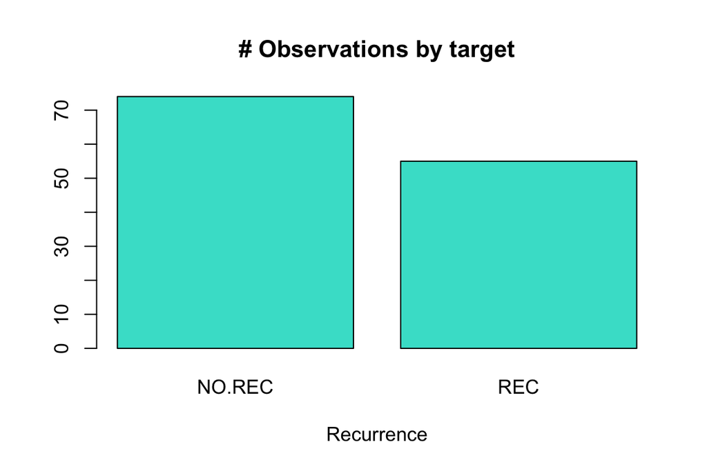

```r
barplot(table(cancer$recurrence),
        main = "# Observations by target",
        xlab = "Recurrence",
        col = "turquoise")
```

We have available some more data about individuals with non-recurrence than from the ones with re-appearance of disease. The difference is small so it might not affect to the prediction.

```r
NA_by_col <- sapply(cancer, FUN = function(x) sum(is.na(x)))
(NA_by_col <- sort(NA_by_col[NA_by_col > 0], decreasing = TRUE))
```

```
##       LORF1_VSAMEDEMNEMK         CNN3_GFHTTIDIGVK       GBP1_GFSLGSTVQSHTK
##                       36                       29                       13
##     CLIC4_HPESNTAGMDIFAK          TLN1_ALEATTEHIR         MIEN1_LENGGFPYEK
##                       13                       12                       12
##        PIGR_TDISMSDFENSR        NOP16_YMVENHGEDYK         PSMD7_IVGWYHTGPK
##                       11                       11                       10
##          TGM2_NEFGEIQGDK            BAG5_EVVEDINK DDX1_GIDIHGVPYVINVTLPDEK
##                        9                        7                        7
##          LBP_LAEGFPLPLLK         STK4_LGEGSYGSVYK            BGH3_IPSETLNR
##                        7                        7                        6
##       ACTN1_LAILGIHNEVSK          SAHH2_YSFMATVTK   ANXA6_DLEADIIGDTSGHFQK
##                        6                        6                        4
##            ADA_EGVVYVEVR            DPP2_LDHFNFER   BUD23_AGFSGGMVVDYPNSAK
##                        4                        4                        3
##       LONM_FSVGGMTDVAEIK     IL16_LLSTQAEESQGPVLK           NSDHL_QDLYPALK
##                        3                        3                        3
##    ANXA6_SLEDALSSDTSGHFR        BAG5_YLDLEEEADTTK     AL1A2_IFINNEWQNSESGR
##                        3                        3                        2
##    KCRB_LAVEALSSLDGDLAGR        BGH3_LTLLAPLNSVFK           URP2_LTQLYEQAR
##                        2                        2                        2
##           TPM1_MEIQEIQLK           SRBS2_NEDELELR         TPM1_QLEDELVSLQK
##                        2                        2                        2
##          STK4_AVGDEMGTVR         CNN3_DYQYSDQGIDY       MYH9_IAQLEEQLDNETK
##                        1                        1                        1
##         LONM_LAQPYVGVFLK        LORF1_QANVQIQEIQR      URP2_TASGDYIDSSWELR
##                        1                        1                        1
##          SAHH2_TTDVMFGGK           SRSF2_YGGGGYGR
##                        1                        1
```

There are only a few variables with a considerable amount of missing values, so in general we will benefit of having the information about all the individuals.

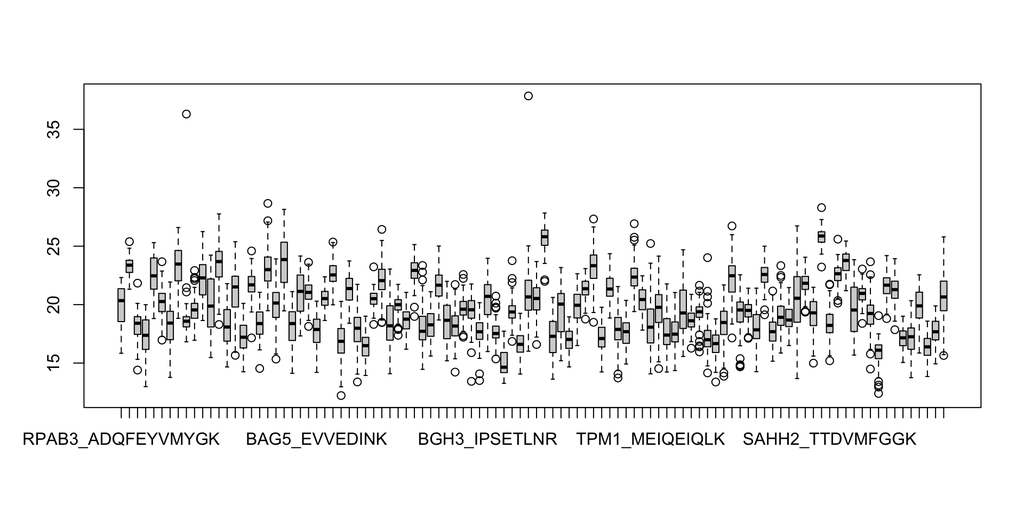

```r
boxplot(cancer[, 1:(ncol(cancer) - 2)])
```

# Data preparation

Before moving into the fitting of any model, data should be prepared. As just mentioned, scaling is not necessary when working with trees, so the only step we are going to consider is splitting the data into 2 sets: a training set $(2 / 3)$ and a test set $(1 / 3)$.

```r
set.seed(1234)
n <- nrow(cancer)
train_prop <- 2/3
train_ind <- sample(1:n, train_prop * n)
cancer_train <- cancer[train_ind, ]
cancer_test <- cancer[-train_ind, ]
```

# Model Fitting

In this section, we will fit two models:

1. A Random Forest Classifier.
2. A Gradient Boosting Classifier.

For each of them, we will do the required tunning, train it and do a proper test-based evaluation.

## Random Forest Classifier

First, we will tune the number of trees and number of variables per node by implementing a grid search procedure. For each combination of hyperparameters, we will compute the model accuracy in the test set and also its out-of-bag accuracy.

```r
library(randomForest)
ntree <- seq(50, 500, 50)
nvar <- floor(ncol(cancer_train)/seq(3, 8, 1))
RF_errTable <- data.frame(Model = character(),
                          NumTree = integer(),
                          NumVar = integer(),
                          OOBacc = numeric(),
                          TESTacc = numeric())
errValue <- 1
for (numTrees in ntree) {
  for (numVars in nvar) {
    set.seed(1234)
    RF_cancer <- randomForest(recurrence ~ .,
                              data = cancer_train,
                              mtry = numVars,
                              ntree = numTrees,
                              importance = TRUE,
                              na.action = na.roughfix)

    yhat <- predict(RF_cancer, newdata = cancer_test)
    good_pred <- na.omit(yhat == cancer_test$recurrence)
    test_acc <- sum(good_pred) / length(good_pred)

    oob_acc <- 1 - RF_cancer$err.rate[numTrees, 1]

    RF_errTable[errValue, ] <-  c(Model = "Random Forest",
                                  NumTree = numTrees,
                                  NumVar = numVars,
                                  OOBacc = round(100*oob_acc, 2),
                                  TESTacc = round(100*test_acc, 2))
    errValue <- errValue + 1
  }
}
```

To choose the best combination of hyperparameters, we will consider a weighted mean between the test accuracy (70%) and the OOB accuracy (30%):

```r
RF_errTable$weight_acc <- 0.7*as.numeric(RF_errTable$TESTacc) +
  0.3*as.numeric(RF_errTable$OOBacc)
weight_order <- order(RF_errTable$weight_acc, decreasing = TRUE)
(best_rf <- head(RF_errTable[weight_order, ], 1))
```

|  | Model | NumTree | NumVar | OOBacc | TESTacc | weight_acc |
| --- | --- | --- | --- | --- | --- | --- |
| 5 | Random Forest | 50 | 14 | 53.49 | 77.78 | 70.493 |

The best random forest is the one with 50 trees and 14 variables per node. So we use this values to fit again the corresponding model:

```r
set.seed(1234)
RF_cancer <- randomForest(recurrence ~ .,
                          data = cancer_train,
                          mtry = as.integer(best_rf$NumVar),
                          ntree = as.integer(best_rf$NumTree),
                          importance = TRUE,
                          na.action = na.roughfix)
RF_cancer
```

```
##
## Call:
##  randomForest(formula = recurrence ~ ., data = cancer_train, mtry = as.integer(best_rf$NumVar),      ntree = as.integer(best_rf$NumTree), importance = TRUE, na.action = na.roughfix)
##                Type of random forest: classification
##                      Number of trees: 50
## No. of variables tried at each split: 14
##
##         OOB estimate of  error rate: 46.51%
## Confusion matrix:
##        NO.REC REC class.error
## NO.REC     38  13   0.2549020
## REC        27   8   0.7714286
```

By having a look at the confusion matrix, we see that the models performs poor when trying to classify individuals with recurrence. This could be because, as wee seen in the exploratory data analysis, we have fewer observations of these cases. However, it achieves a high classification rate for the non-recurrent observations. For the test set:

```r
library(caret)
set.seed(1234)
yhat <- as.factor(predict(RF_cancer, newdata = cancer_test))
(confMat_test <- confusionMatrix(yhat, cancer_test$recurrence))
```

```
## Confusion Matrix and Statistics
##
##           Reference
## Prediction NO.REC REC
##     NO.REC     12   3
##     REC         1   2
##
##                Accuracy : 0.7778
##                  95% CI : (0.5236, 0.9359)
##     No Information Rate : 0.7222
##     P-Value [Acc > NIR] : 0.4114
##
##                   Kappa : 0.3684
##
##  Mcnemar's Test P-Value : 0.6171
##
##             Sensitivity : 0.9231
##             Specificity : 0.4000
##          Pos Pred Value : 0.8000
##          Neg Pred Value : 0.6667
##              Prevalence : 0.7222
##          Detection Rate : 0.6667
##    Detection Prevalence : 0.8333
##       Balanced Accuracy : 0.6615
##
##        'Positive' Class : NO.REC
##
```

Let’s have a look at which variables are the most relevant in the prediction:

```r
var_imp <- RF_cancer$importance
var_imp <- var_imp[order(abs(var_imp[, 3]), decreasing = TRUE), ]
head(var_imp, 10)
```

```
##                          NO.REC           REC MeanDecreaseAccuracy
## PSMD7_IVGWYHTGPK  -0.0035508021 -0.0133566434         -0.007799406
## LONM_LAQPYVGVFLK  -0.0058888889 -0.0068831169         -0.006394687
## TLN1_VLVQNAAGSQEK  0.0065930736  0.0042077922          0.005441936
## CNN3_DYQYSDQGIDY   0.0032380952  0.0081136249          0.005040522
## PMVK_EAYGAVTQTVR  -0.0056050420 -0.0033566434         -0.004682651
## ANXA1_DITSDTSGDFR  0.0025906120  0.0074005994          0.004510593
## ENAH_LEQEQLER     -0.0013333333 -0.0074178762         -0.004503697
## KCRB_LLIEMEQR      0.0004981706 -0.0109184149         -0.004206937
## LSM8_AEPLNSVAH     0.0078245614 -0.0015384615          0.004059524
## ADA_EGVVYVEVR     -0.0043830228 -0.0007619048         -0.004036354
##                   MeanDecreaseGini
## PSMD7_IVGWYHTGPK         0.4717086
## LONM_LAQPYVGVFLK         0.4142266
## TLN1_VLVQNAAGSQEK        0.5744490
## CNN3_DYQYSDQGIDY         0.7239212
## PMVK_EAYGAVTQTVR         0.3761772
## ANXA1_DITSDTSGDFR        0.7460183
## ENAH_LEQEQLER            0.3926139
## KCRB_LLIEMEQR            0.4629972
## LSM8_AEPLNSVAH           0.4128041
## ADA_EGVVYVEVR            0.4647230
```

The above 10 peptides seem to be the most determinant ones on re-appearance of the disease.

# Models comparison

Compare the predictors based on the adequate metrics and propose a classifier and not more than 10 peptides as the most relevant recurrence biomarkers (the most important variables for your classifier).